# Projet Vendée Globe par Mahmoud Benboubker - MS BGD

```python
import pandas as pd
import numpy as np

import requests
from bs4 import BeautifulSoup
import re

import os
import datetime

import matplotlib.pyplot as plt
import seaborn as sns

from sklearn.model_selection import train_test_split
from sklearn.linear_model import LinearRegression
```

### Récupération des fichiers Excel avec les classements.

La page https://www.vendeeglobe.org/fr/classement donne un classement quasi temps réel de la course (update 6 fois par jour). Ce classement est récupérable en format .xlsv

```python
def clean_ranking(filename):
    """ Nettoyage des données notamment la conversion de statistiques étant en string en entier"""
    columns = ['Rank', 'Nat', 'Skipper', 'Lat', 'Long', 'Cap', 'Vitesse (kts)','VMG', 'Dist_arrivée (nm)', 'DTF', 'DTL']
    df_classement = pd.read_excel("./data/classements/"+filename, skiprows=range(4), usecols=[1, 2, 3, 5, 6, 7, 8, 9, 10, 19, 20], encoding='utf-8', names=columns)
    df_classement["Skipper"] = df_classement["Skipper"].apply(lambda x : str(x).split("\n")[0])
    df_classement.drop(index=range(33, 37), inplace=True)
    df_classement["Nat"] = df_classement["Nat"].apply(lambda x : str(x).split("\n")[1])
    update_time = filename.split('e_')[1][:-5]
    var = datetime.datetime.strptime(str(update_time), '%Y%m%d_%H%M%S').strftime('%Y/%m/%d %H:%M:%S')
    df_classement["Update Time"] = var
    df_classement =  df_classement[~df_classement.Rank.isin(["RET","NL"])]
    df_classement["Rank"] = df_classement["Rank"].apply(lambda x : int(x))
    for label in ["Vitesse (kts)", "VMG","Dist_arrivée (nm)","DTF","DTL"]:
        df_classement[label] = df_classement[label].apply(lambda x : float(x.split(' ')[0]))
    return df_classement

def get_last_classement():
    website = 'https://www.vendeeglobe.org'
    req = requests.get(website + '/fr/classement')
    soup = BeautifulSoup(req.content)
    link_ref = soup.find('a', {"class": "rankings__download"})
    link_ref = link_ref.attrs["href"]
    link = website + link_ref
    filename = link.split('/')[-1]
    r = requests.get(link, allow_redirects=True)
    open("./data/classements/"+filename, 'wb').write(r.content)
    return clean_ranking(filename)
```

```python
get_last_classement().head()
```

|  | Rank | Nat | Skipper | Lat | Long | Cap | Vitesse (kts) | VMG | Dist_arrivée (nm) | DTF | DTL | Update Time |
| --- | --- | --- | --- | --- | --- | --- | --- | --- | --- | --- | --- | --- |
| 0 | 1 | FRA 79 | Charlie Dalin | 39°18.70'S | 06°01.77'E | 71° | 17.1 | 13.4 | 8.5 | 18129.1 | 0.0 | 2020/11/29 08:00:00 |
| 1 | 2 | FRA 59 | Thomas Ruyant | 38°38.42'S | 00°10.92'W | 57° | 19.4 | 11.2 | 9.7 | 18414.9 | 285.7 | 2020/11/29 08:00:00 |
| 2 | 3 | FRA 01 | Jean Le Cam | 37°19.89'S | 01°09.36'W | 90° | 11.9 | 10.9 | 6.0 | 18487.5 | 358.4 | 2020/11/29 08:00:00 |
| 3 | 4 | FRA 85 | Kevin Escoffier | 38°37.24'S | 01°51.11'W | 135° | 17.7 | 16.2 | 8.8 | 18488.1 | 358.9 | 2020/11/29 08:00:00 |
| 4 | 5 | FRA 17 | Yannick Bestaven | 37°55.48'S | 02°04.37'W | 63° | 17.3 | 11.2 | 8.7 | 18513.6 | 384.5 | 2020/11/29 08:00:00 |

L'historique des classements se trouve dans "combobox". Il serait intéressant de pouvoir télécharger les classements depuis le combobox.

```python
def download_classement_historique(heure_date):
    """Telechargement du fichier à l'aide de son nom"""
    website = 'https://www.vendeeglobe.org'
    req = requests.get(website + '/fr/classement/'+heure_date)
    soup = BeautifulSoup(req.content)
    link_ref = soup.find('a', {"class": "rankings__download"})
    if link_ref: ## pour eviter les erreurs si certaines pages n'ont pas de fichiers excel
        link_ref = link_ref.attrs["href"]
        link = website + link_ref
        filename = link.split('/')[-1]
        r = requests.get(link, allow_redirects=True)
        open("./data/classements/"+filename, 'wb').write(r.content)
def get_rankings_archives() :
    """Recupération des noms de fichiers depuis le combobox"""
    website = 'https://www.vendeeglobe.org'
    req = requests.get(website + '/fr/classement')
    soup = BeautifulSoup(req.content)
    combobox_ref = soup.find('select', {"class": "form__input m--select onsubmit-rank"})
    historique_list = combobox_ref.find_all('option')
    historique_list.pop(0)
    historique_date_heure = [tag.attrs['value'] for tag in historique_list]
    for elt in historique_date_heure:
        download_classement_historique(elt)
def get_all_rankings():
    """Retourne une concaténation des classements historiques en DataFrame"""
    get_rankings_archives()
    classements = os.listdir('./data/classements')
    classements_listes = []
    for cls in classements:
        classements_listes.append(clean_ranking(cls))
    df = pd.concat(classements_listes)
    df.to_csv('./data/all_rankings.csv')
    return df
```

```python
get_all_rankings().head()
```

|  | Rank | Nat | Skipper | Lat | Long | Cap | Vitesse (kts) | VMG | Dist_arrivée (nm) | DTF | DTL | Update Time |
| --- | --- | --- | --- | --- | --- | --- | --- | --- | --- | --- | --- | --- |
| 0 | 1 | FRA 18 | Louis Burton | 46°24.46'N | 01°50.48'W | 241° | 17.7 | 17.5 | 0.3 | 24293.9 | 0.0 | 2020/11/08 14:00:00 |
| 1 | 2 | MON 10 | Boris Herrmann | 46°24.34'N | 01°49.82'W | 241° | 11.1 | 10.9 | 0.4 | 24294.2 | 0.4 | 2020/11/08 14:00:00 |
| 2 | 3 | FRA 8 | Jérémie Beyou | 46°24.91'N | 01°49.99'W | 244° | 15.5 | 15.5 | 0.5 | 24294.3 | 0.5 | 2020/11/08 14:00:00 |
| 3 | 4 | FRA 59 | Thomas Ruyant | 46°24.71'N | 01°49.68'W | 244° | 13.2 | 13.1 | 0.7 | 24294.5 | 0.6 | 2020/11/08 14:00:00 |
| 4 | 5 | FRA 53 | Maxime Sorel | 46°24.59'N | 01°49.56'W | 246° | 10.9 | 10.9 | 0.2 | 24294.5 | 0.6 | 2020/11/08 14:00:00 |

### Extraction des fiches techniques pour chacun des voiliers.

```python
def get_bateau_infos() :
    website = 'https://www.vendeeglobe.org/fr/glossaire'
    req = requests.get(website)
    soup = BeautifulSoup(req.content.decode('utf-8'))
    bateaux = []
    for elt in soup.find('section', {"class": "boats-list"}).find_all("div", {"class" : "boats-list__popup-infos"}) :
        bateau = {}
        bateau["Nom bateau"] = elt.find("h3", {"class": "boats-list__popup-title" }).text
        for i in elt.find_all('li') :
            key = i.text.split(' : ')[0]
            value = i.text.split(' : ')[1]
            bateau[key] = value
        bateaux.append(bateau)
    skippers = [ x.text for x in soup.find_all("span", {"class" : "boats-list__skipper-name"}, text= True)]
    for i in range(len(skippers)):
        bateaux[i]["Skipper"] = skippers.pop(0)
    df = pd.DataFrame(bateaux)
    df = df.replace('Sam Davies', 'Samantha Davies')
    df = df.replace('foiler','foils')
    df['Foils'] = df['Nombre de dérives'].str.contains('foil')
    df["Longueur"] = 18.28
    df["Tirant d'eau"] = 4.5
    df["Skipper"] = df["Skipper"].apply(lambda x : x.title())
    for label in ["Hauteur mât","Largeur"]:
        df[label] = df[label].str.replace('m',' ')
        df[label] = df[label].str.replace(',','.').apply(lambda x : float(x))
    for label in ["Surface de voiles au près","Surface de voiles au portant"]:
        df[label] = df[label].str.replace('m²',' ')
        df[label] = df[label].str.replace('m2',' ')
        df[label] = df[label].str.replace(',','.').apply(lambda x : float(x))
    label = "Déplacement (poids)"
    df[label] = df[label].str.replace('tonnes','t')
    df[label] = df[label].str.replace('NC','8')
    df[label] = df[label].str.replace('nc','8')
    df[label] = df[label].str.replace('t',' ')
    df[label] = df[label].str.replace(',','.').apply(lambda x : float(x))
    df.to_csv("./data/bateaux/bateaux_info.csv")
    return df
```

```python
get_bateau_infos().head()
```

|  | Nom bateau | Numéro de voile | Anciens noms du bateau | Architecte | Chantier | Date de lancement | Longueur | Largeur | Tirant d'eau | Déplacement (poids) | Nombre de dérives | Hauteur mât | Voile quille | Surface de voiles au près | Surface de voiles au portant | Skipper | Foils |
| --- | --- | --- | --- | --- | --- | --- | --- | --- | --- | --- | --- | --- | --- | --- | --- | --- | --- |
| 0 | NEWREST - ART & FENÊTRES | FRA 56 | No Way Back, Vento di Sardegna | VPLP/Verdier | Persico Marine | 01 Août 2015 | 18.28 | 5.85 | 4.5 | 7.0 | foils | 29.0 | monotype | 320.0 | 570.0 | Fabrice Amedeo | True |
| 1 | PURE - Best Western® | FRA 49 | Gitana Eighty, Synerciel, Newrest-Matmut | Bruce Farr Design | Southern Ocean Marine (Nouvelle Zélande) | 08 Mars 2007 | 18.28 | 5.80 | 4.5 | 9.0 | 2 | 28.0 | acier forgé | 280.0 | 560.0 | Romain Attanasio | False |
| 2 | TSE - 4MYPLANET | FRA72 | Famille Mary-Etamine du Lys, Initiatives Coeur... | Marc Lombard | MAG France | 01 Mars 1998 | 18.28 | 5.54 | 4.5 | 9.0 | 2 | 29.0 | acier | 260.0 | 580.0 | Alexia Barrier | False |
| 3 | Maître CoQ IV | 17 | Safran 2 - Des Voiles et Vous | Verdier - VPLP | CDK Technologies | 12 Mars 2015 | 18.28 | 5.80 | 4.5 | 8.0 | foils | 29.0 | acier mécano soudé | 310.0 | 550.0 | Yannick Bestaven | True |
| 4 | CHARAL | 08 | NaN | VPLP | CDK Technologies | 18 Août 2018 | 18.28 | 5.85 | 4.5 | 8.0 | foils | 29.0 | acier | 320.0 | 600.0 | Jérémie Beyou | True |

### Rapprochement des données des voiliers avec celle des classements.

```python
def merge_ranks_bateau():
    df_bateaux = pd.read_csv("./data/bateaux/bateaux_info.csv",index_col=[0])
    df_ranks = pd.read_csv("./data/all_rankings.csv", index_col=[0])
    return df_ranks.merge(df_bateaux, on ="Skipper")
```

```python
merge_ranks_bateau().head()
```

|  | Rank | Nat | Skipper | Lat | Long | Cap | Vitesse (kts) | VMG | Dist_arrivée (nm) | DTF | ... | Longueur | Largeur | Tirant d'eau | Déplacement (poids) | Nombre de dérives | Hauteur mât | Voile quille | Surface de voiles au près | Surface de voiles au portant | Foils |
| --- | --- | --- | --- | --- | --- | --- | --- | --- | --- | --- | --- | --- | --- | --- | --- | --- | --- | --- | --- | --- | --- |
| 0 | 1 | FRA 18 | Louis Burton | 46°24.46'N | 01°50.48'W | 241° | 17.7 | 17.5 | 0.3 | 24293.9 | ... | 18.28 | 5.8 | 4.5 | 7.6 | foils | 28.0 | acier | 300.0 | 600.0 | True |
| 1 | 11 | FRA 18 | Louis Burton | 46°21.73'N | 03°17.02'W | 271° | 20.3 | 16.4 | 10.2 | 24241.7 | ... | 18.28 | 5.8 | 4.5 | 7.6 | foils | 28.0 | acier | 300.0 | 600.0 | True |
| 2 | 8 | FRA 18 | Louis Burton | 46°16.47'N | 04°47.79'W | 262° | 12.3 | 10.1 | 6.2 | 24189.6 | ... | 18.28 | 5.8 | 4.5 | 7.6 | foils | 28.0 | acier | 300.0 | 600.0 | True |
| 3 | 11 | FRA 18 | Louis Burton | 46°28.36'N | 07°03.84'W | 294° | 13.9 | 0.4 | 6.9 | 24143.2 | ... | 18.28 | 5.8 | 4.5 | 7.6 | foils | 28.0 | acier | 300.0 | 600.0 | True |
| 4 | 18 | FRA 18 | Louis Burton | 46°45.59'N | 08°02.46'W | 300° | 11.6 | -1.5 | 5.8 | 24142.9 | ... | 18.28 | 5.8 | 4.5 | 7.6 | foils | 28.0 | acier | 300.0 | 600.0 | True |

5 rows × 28 columns

### Corrélation et régression linéaire entre le classement (rang) et la vitesse utile (VMG) des voiliers.

```python
df = pd.read_csv('./data/all_rankings.csv', index_col=[0] )
df =  df[~df.Rank.isin(["RET","NL"])]
x1 = df["Rank"]
x2 = df["VMG"]
```

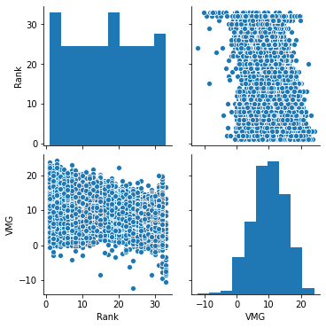

```python
sns.pairplot(df[["Rank","VMG"]]);
```

Le pairplot ne nous permet pas de déduire une corrélation entre les deux métriques.  
Par la suite, nous allons calculer le coefficient de corrélation et nous allons également calculer le "VMG moyen" par le rang

```python
corr = np.corrcoef(x1,x2)[0][1]
corr
```

```
-0.36528523478995123
```

Le coefficient de corrélation est négatif donc si la VMG augmente alors le classement du skipper s'améliore

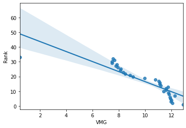

```python
df = df[["Rank","VMG"]]
df = df.groupby('Rank').mean().reset_index()
sns.regplot(df['VMG'],df['Rank']);
```

On remarque bien par cette régréssion linéaire, en utilisant le VMG moyen, on remarque si le VMG augmente alors le bateau est mieux classé.  
La régression linéaire faite précédemment était sur le VMG moyen par rang. Faisons une régréssion linéaire de la VMG pour prédire le rang.

```
score 0.16175845217973572
```

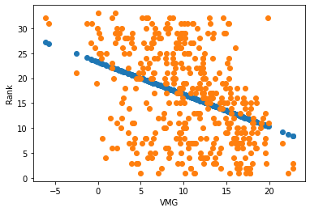

```python
X_train, X_test, y_train, y_test = train_test_split(np.array(x2.values).reshape(len(x2.values),1), x1.values, test_size=0.1, random_state=42)
reg = LinearRegression().fit(X_train, y_train)
print("score",reg.score(X_test, y_test))
plt.scatter(X_test,reg.predict(X_test))
plt.scatter(X_test, y_test)
plt.xlabel("VMG")
plt.ylabel("Rank");
```

Le score obtenu est très faible, le VMG n'est pas une métrique suffisante pour prédire le rang.

### Impact de la présence d'un foil sur le classement et la vitesse des voiliers.

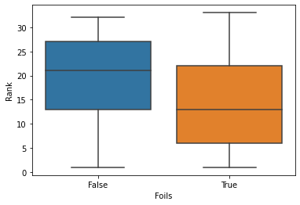

```python
df = merge_ranks_bateau()
df =  df[~df.Rank.isin(["RET","NL"])]
df["Rank"] = df["Rank"].apply(lambda x : int(x))
sns.boxplot(y = df["Rank"], x = df["Foils"]);
```

On remarque les voiliers possédant un foil ont tendance à être mieux classés.

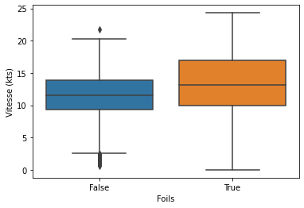

```python
sns.boxplot(y = df["Vitesse (kts)"], x = df["Foils"]);
```

On remarque que les voiliers possédant un foil ont une meilleure vitesse dans la course.  
On peut conclure que posseder un foil donne un avantage.

### Visualisation de la distance parcourue par voilier.

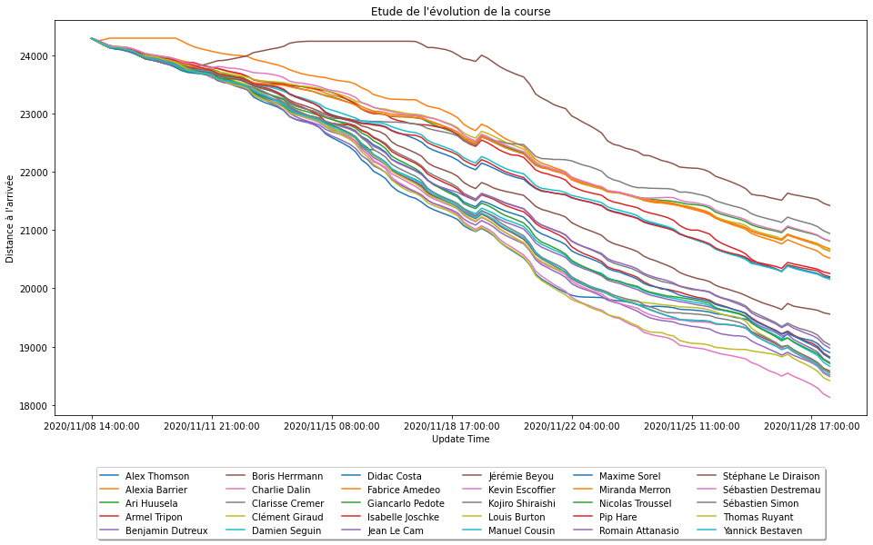

```python
pd.pivot_table(merge_ranks_bateau(), values='DTF', index='Update Time', columns='Skipper').plot(figsize=[16,8])
plt.title("Etude de l'évolution de la course")
plt.ylabel("Distance à l'arrivée")
plt.legend(title=None, bbox_to_anchor=(0.5, -0.12), loc='upper center', ncol=6, fancybox=True, shadow=True)
plt.show()
```

### Etude de l'évolution des vitesses en fonction des skippers

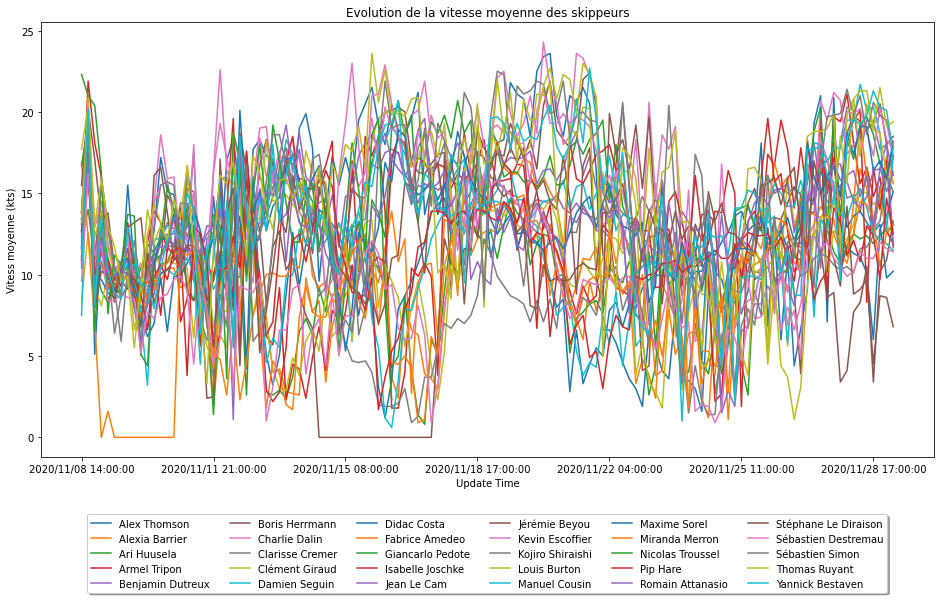

```python
pd.pivot_table(merge_ranks_bateau(), values='Vitesse (kts)', index='Update Time', columns='Skipper', aggfunc='mean').plot(figsize=[16,8])
plt.title("Evolution de la vitesse moyenne des skippeurs")
plt.ylabel("Vitess moyenne (kts)")
plt.legend(title=None, bbox_to_anchor=(0.5, -0.12), loc='upper center', ncol=6, fancybox=True, shadow=True)
plt.show()
```

### Distance parcourue par les skippers les derniers 24h

```python
def get_last_24h():
    filename = os.listdir('./data/classements')[-1]
    columns = ['Rank', 'Nat', 'Skipper', 'Lat', 'Long', 'Cap', 'Vitesse (kts)','VMG', 'Dist_arrivée (nm)', 'DTF', 'DTL']
    df_classement = pd.read_excel("./data/classements/"+filename, skiprows=range(4), usecols=[1, 2, 3, 5, 6, 15, 16, 17, 18, 19, 20], encoding='utf-8', names=columns)
    df_classement["Skipper"] = df_classement["Skipper"].apply(lambda x : str(x).split("\n")[0])
    df_classement.drop(index=range(33, 37), inplace=True)
    df_classement["Nat"] = df_classement["Nat"].apply(lambda x : str(x).split("\n")[1])
    update_time = filename.split('e_')[1][:-5]
    var = datetime.datetime.strptime(str(update_time), '%Y%m%d_%H%M%S').strftime('%Y/%m/%d %H:%M:%S')
    df_classement["Update Time"] = var
    df_classement =  df_classement[~df_classement.Rank.isin(["RET","NL"])]
    df_classement["Rank"] = df_classement["Rank"].apply(lambda x : int(x))
    for label in ["Vitesse (kts)", "VMG","Dist_arrivée (nm)","DTF","DTL"]:
        df_classement[label] = df_classement[label].apply(lambda x : float(x.split(' ')[0]))
    return df_classement
```

```python
def metrique_24h(metrique, ylabel,titre):
    df = get_last_24h().sort_values(by=[metrique], ascending=False)
    plt.figure(figsize=(15,9))
    plt.scatter(df["Skipper"], df[metrique], s=70)
    plt.xticks(rotation=90)
    plt.yticks(size=15)
    plt.xticks(size=15)
    plt.title(titre, size=20)
    plt.ylabel(ylabel)
    plt.grid()
    plt.show()
```

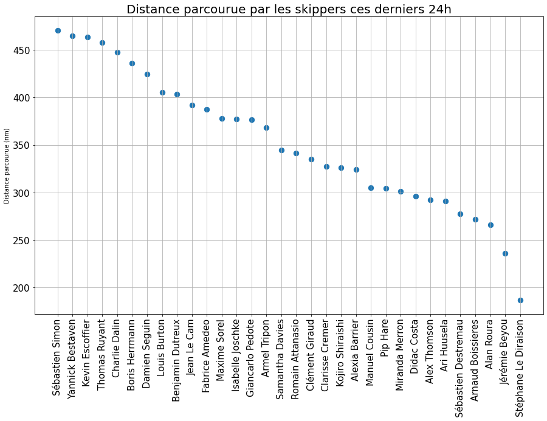

```python
metrique_24h('Dist_arrivée (nm)', "Distance parcourue (nm)","Distance parcourue par les skippers ces derniers 24h")
```

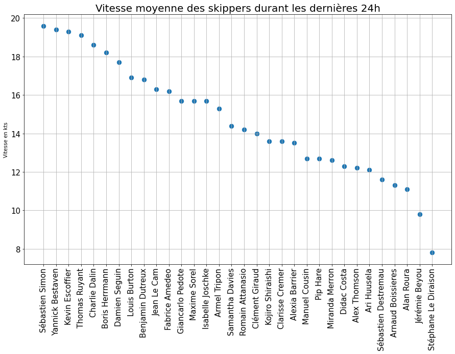

```python
metrique_24h('Vitesse (kts)', "Vitesse en kts","Vitesse moyenne des skippers durant les dernières 24h")
```

```python
import random
from ipyleaflet import Map, basemaps, basemap_to_tiles, Marker, AntPath, CircleMarker, Popup, AwesomeIcon, projections, LayersControl, LayerGroup
from ipywidgets import HTML
```

```python
def dms_to_dec(position):
    temp = re.split("\W", position)
    pos = 1 if temp[3] in ["N", "E"] else -1
    return (float(temp[0]) + float(temp[1])/60 + float(temp[2])/3600) * pos

def get_parcours():
    df = merge_ranks_bateau()
    df.dropna(inplace=True) # Suppression des données manquantes
    parcours = df.loc[:, ["Skipper", "Update Time"]]
    parcours["Lat"] = df["Lat"].apply(dms_to_dec)
    parcours["Long"] = df["Long"].apply(dms_to_dec)
    return parcours
```

```python
def add_course(m, skipper_name, parcours):
    col = "#%06x" % random.randint(0, 0xFFFFFF)
    course = parcours.groupby('Skipper').get_group(skipper_name).sort_values("Update Time")[["Lat", "Long"]].values.tolist()
    marker = CircleMarker(location=course[-1], color=col, radius=5)
    path = AntPath(locations=course, color=col)
    message = HTML(skipper_name)
    layer_group = LayerGroup(name=skipper_name, layers=(path, marker))
    m.add_layer(layer_group)
    marker.popup = message


def generate_course_map(parcours):
    skipper_list = parcours["Skipper"].unique().tolist()
    m = Map(
        basemap=basemap_to_tiles(basemaps.Esri.WorldImagery),
        center=(25, 2),
        zoom=2,
        close_popup_on_click=True
        )
    for skipper in skipper_list:
        add_course(m, skipper, parcours)
    control = LayersControl(position='topright')
    m.add_control(control)
    return m
```

```python
generate_course_map(get_parcours())
```

### Machine Learning

```python
from sklearn.model_selection import train_test_split
from sklearn.ensemble import RandomForestClassifier
from sklearn.neighbors import KNeighborsClassifier
from sklearn.metrics import classification_report
from sklearn.linear_model import LogisticRegression
```

#### Prédiction de la présence d'un foil dans un voilier

```python
def count_days(date) -> int:
    return (datetime.datetime.today() - date).days
```

```python
df = get_bateau_infos()
convert_fr_ang = {'Janvier': 'January', 'Février': 'February', 'Mars': 'March', 'Avril': 'April', 'Mai': 'May', 'Juin': 'June', 'Juillet': 'July', 'Août': 'August','Septembre': 'September', 'Octobre': 'October', 'Novembre': 'November', 'Décembre': 'December'}
df["Date de lancement"] = df["Date de lancement"].replace(convert_fr_ang, regex=True).apply(lambda date: datetime.datetime.strptime(date, '%d %B %Y'))
df["Date de lancement"] = df["Date de lancement"].apply(count_days)
df.drop("Skipper", axis=1, inplace=True)
df.dropna(inplace=True)
X = df[['Date de lancement', 'Longueur', 'Largeur', "Tirant d'eau",'Déplacement (poids)', 'Hauteur mât', 'Surface de voiles au près','Surface de voiles au portant', 'Foils']]
X_train, X_test, y_train, y_test = train_test_split(X, df["Foils"], test_size=0.33, random_state=42)
```

```python
reglog = LogisticRegression(random_state=42)
forest = RandomForestClassifier(max_depth=5, n_estimators=10, random_state=42)
knn = KNeighborsClassifier(3)
models = [reglog, forest, knn]
```

```python
# Entraînement des modèles
for model in models:
    model.fit(X_train, y_train)
```

```python
print("Regression Logistique")
print(classification_report(y_test, reglog.predict(X_test), target_names=["True", "False"]))
```

```
Regression Logistique
              precision    recall  f1-score   support

        True       0.60      0.75      0.67         4
       False       0.67      0.50      0.57         4

    accuracy                           0.62         8
   macro avg       0.63      0.62      0.62         8
weighted avg       0.63      0.62      0.62         8
```

```python
print("KNN")
print(classification_report(y_test, knn.predict(X_test), target_names=["True", "False"]))
```

```
KNN
              precision    recall  f1-score   support

        True       0.75      0.75      0.75         4
       False       0.75      0.75      0.75         4

    accuracy                           0.75         8
   macro avg       0.75      0.75      0.75         8
weighted avg       0.75      0.75      0.75         8
```

```python
print("Random Forest")
print(classification_report(y_test, forest.predict(X_test), target_names=["True", "False"]))
```

```
Random Forest
              precision    recall  f1-score   support

        True       1.00      1.00      1.00         4
       False       1.00      1.00      1.00         4

    accuracy                           1.00         8
   macro avg       1.00      1.00      1.00         8
weighted avg       1.00      1.00      1.00         8
```

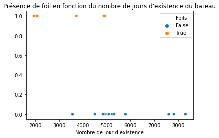

```python
sns.scatterplot(x=df["Date de lancement"], y=df["Foils"], hue=temp["Foils"])
plt.xlabel("Nombre de jour d'existence")
plt.ylabel("")
plt.title("Présence de foil en fonction du nombre de jours d'existence du bateau")
plt.show()
```

Les bateaux les plus récents possédent des foils tandis que les plus anciens n'en possédent pas